# Predicting Road Crash Severity in NSW

## STAT5003 – W11_G09

### Ryan Wang · Yifei Huang · JayC · Steven · Carmen Feng

### University of Sydney

# 1. Project Topic

- **Topic:** Predicting the severity of NSW road crashes based on scene and environmental factors.

- **Goal:** Develop classification models to automatically assign each crash record to its most likely severity category.

- **Target Variable:** *Degree of Crash – Detailed*
  → *Fatal, Serious Injury, Moderate Injury, Minor/Other Injury, NonCasualty (towaway)*

- **Context:** Based on NSW crash records (2019–2023) provided by Transport for NSW Open Data Hub.

# 2. Research Question and Significance

**Research Question:**

> Can machine learning algorithms accurately predict crash severity
> from NSW crash-scene features, and which model performs best?

**Why It Matters:**

- NSW reports **375+ road deaths and over 10,000 serious injuries per year** (as of June 2024).
- Predicting crash severity supports **risk triage** and **resource allocation** for road safety.
- Contributes to **data-driven transport policy design** and **safer transportation systems** across NSW.

**Our Approach:**

- We address this question by applying and comparing several machine learning models in later sections.

# 3. Data Processing

**Goal:** Prepare NSW crash data (2019–2023) for reliable analysis
**Main Steps:**
1️⃣ Data loading & type conversion
2️⃣ Missing data analysis
3️⃣ Duplicate & outlier review

### Data Loading & Type Conversion

- Loaded crash records from Transport for NSW Open Data Hub.
- Converted variable types:
  - *Categorical:* Weather, Road surface, Month, Day of week
  - *Numeric:* Speed limit, No. of vehicles, Traffic units
- “Unknown” entries treated as missing (NA).
- Crash ID kept as a unique identifier (not used for modelling).

### Data Cleaning Insights

**Missing Data Analysis**
- Calculated missing % per variable
- Removed variables with **>95% missing** (e.g., *Primary hazardous feature*)
- Reason: minimal usable information; unstable for modelling

**Duplicate & Outlier Review**
- No duplicates found (unique Crash IDs)
- Outliers in *No. killed*, *No. seriously injured*, *Speed limit*
- Decision: **keep outliers** – reflect real severe crashes

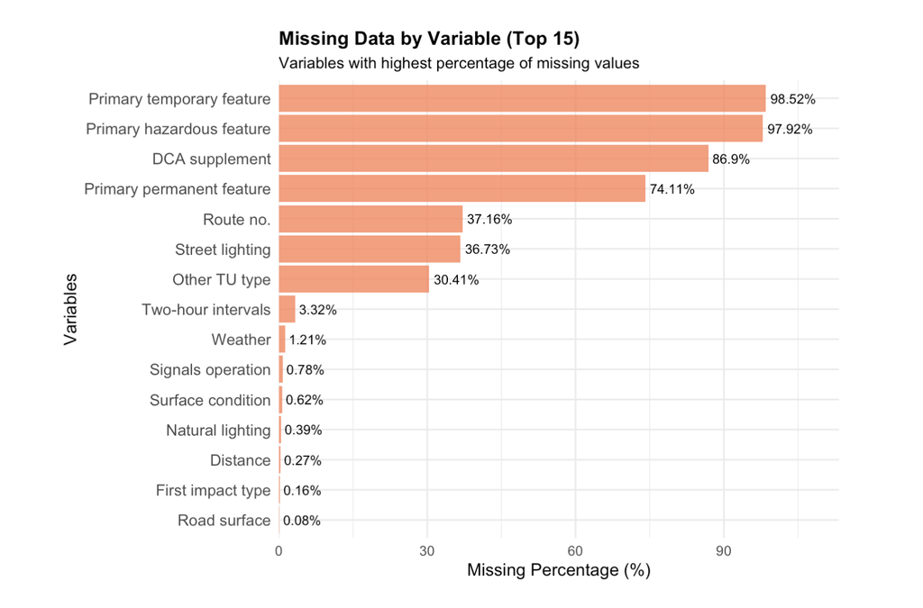

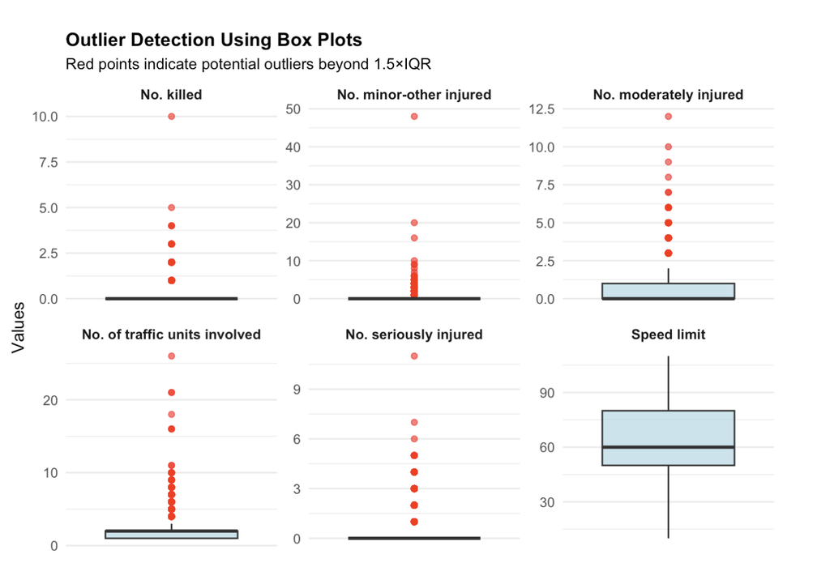

# 4. Data Overview

**4.1 Key Distributions**
- **Speed limits** are **bimodal**: urban (50–60) vs highway (80–100); median ≈ **60 km/h**
- **Class balance** is **highly skewed**: *Fatal* ≪ *Non-casualty*

**Insights**
- Data reflect both **urban** & **highway** contexts
- Severe **imbalance** must be considered in modelling/evaluation

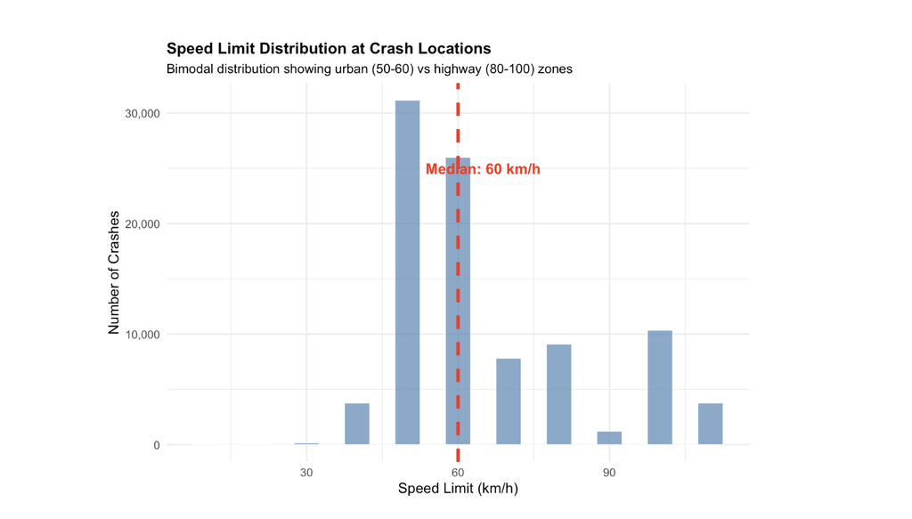

[figure not shown]

# 4. Data Overview

**4.2 Categorical Patterns & Relationships**
- Higher **speed limits** → larger share of **Severe/Fatal** outcomes
- Visual confirms **speed–severity correlation**

**4.3 PCA (EDA only)**
- **Top PCs explain majority of variance**
- **Used for structure check (no leakage)**

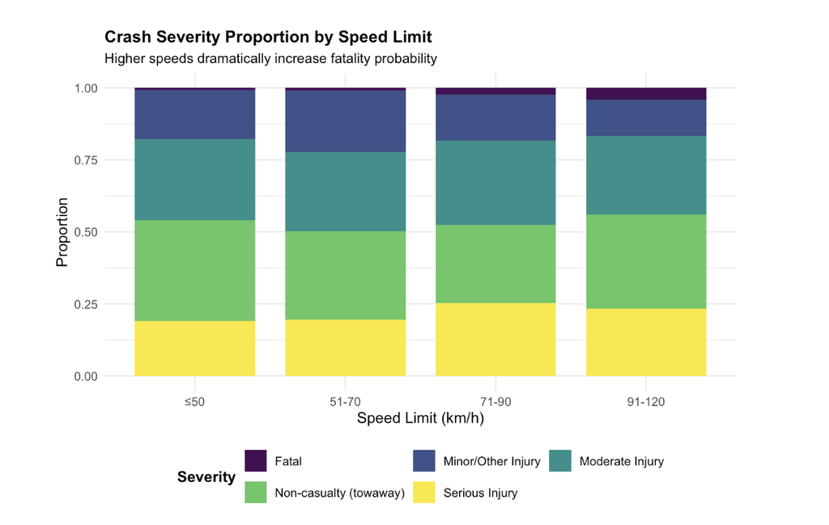

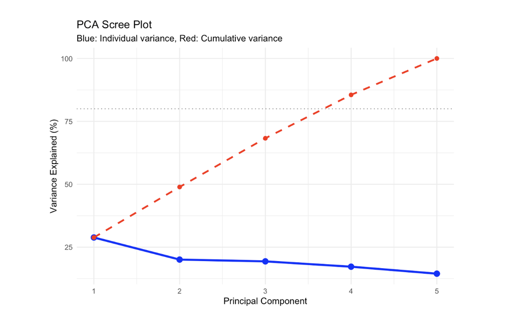

# 5. Feature Engineering

# Feature Engineering — What & Why

### Make signals obvious, remove leakage, keep it honest

**Remove leakage**
- Casualty counts, severity codes, IDs

**Add signals**
- Temporal, Environmental, Road/Location
- Vehicle/Traffic, **Risk interactions**

**Keep it honest**
- Split **before** selection
- Fit on **train only**

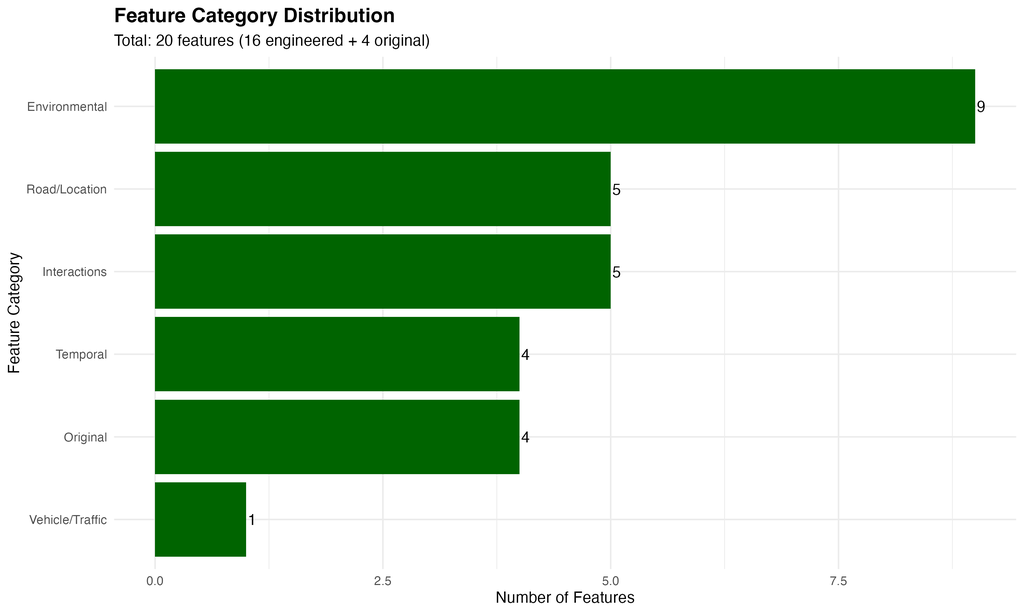

# Which Features Drive Prediction?

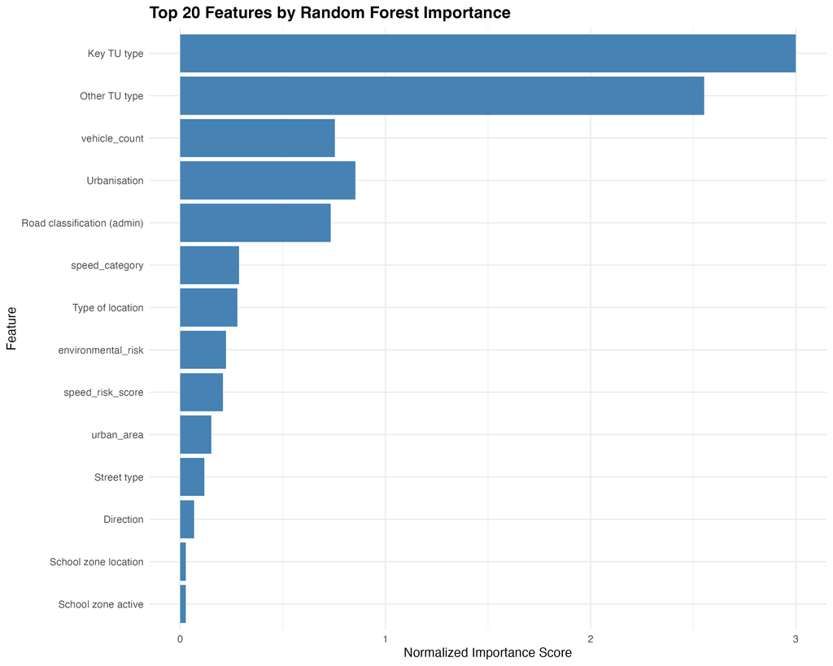

**Vulnerable road users** (Key TU, Other TU) and **vehicle count** dominate, followed by **urbanization** and **road classification**.

# Balanced Feature Selection Strategy

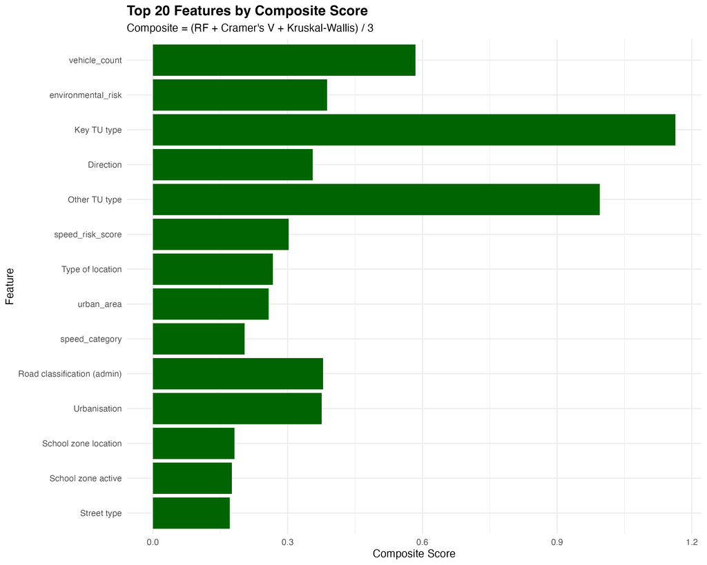

**Composite** = (RF + Cramér's V + Kruskal-Wallis) / 3 — balances predictive power with statistical association.

# Feature Redundancy Check

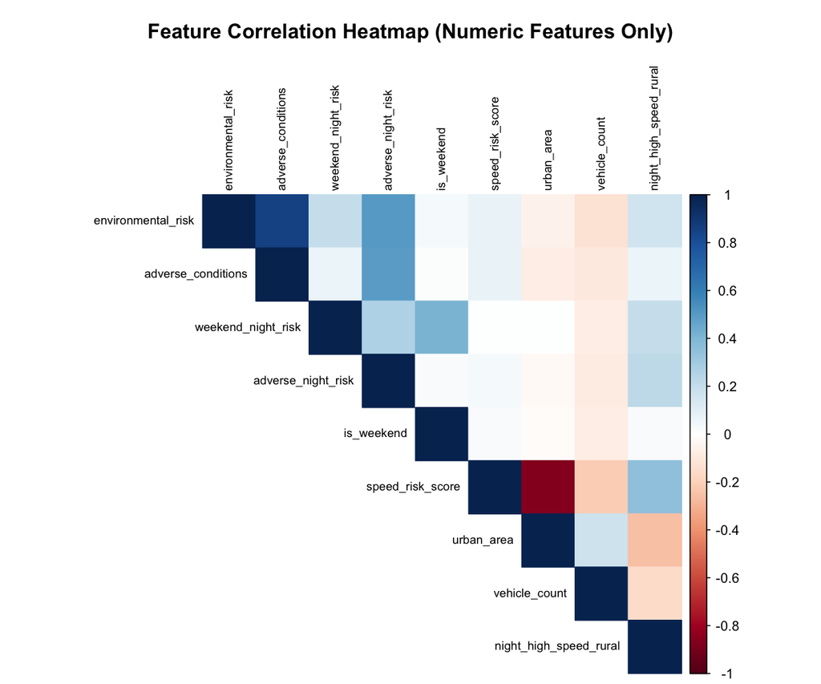

# Feature Engineering — Key Takeaways

**1. Balanced approach**
Model-driven (RF) + theory-driven (statistics)

**3. Signal hierarchy**
- **Vulnerable users** dominate
- **Traffic context** matters
- **Environment** supports

**4. Honest validation**
- Stratified split preserves class proportions
- Train-only fitting avoids leakage
- Unbiased evaluation guaranteed

**Bottom line:**
Comprehensive feature set balances interpretability with predictive power.

# 6. Modeling

# 6.1 Logistic Regression

**Model Concept**
- **Interpretable linear model** for multi-class classification.
- Predicts probabilities via **multinomial (softmax)** function.
- Uses **elastic net** (L1/L2) for regularization and feature selection.

**Model Approach**
- **Multinomial LR** (`glmnet`) with **class weighting**.
- **5-fold CV** grid search: α={0, 0.5, 1}, optimized by Macro-F1.
- Best: α=0 (Ridge), λ=0.0106 | N: 65,445/28,046

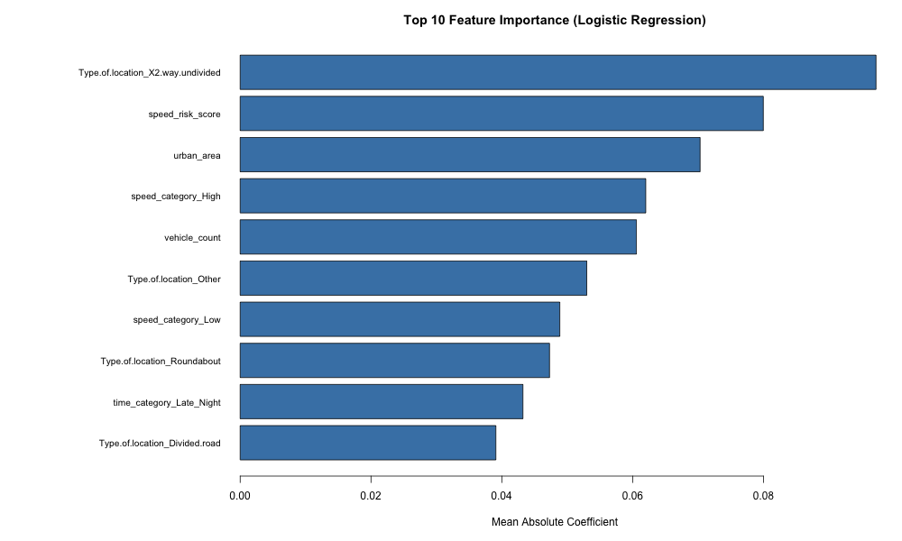

Test: Macro-ROC-AUC **0.594**, Macro-F1 **0.205**, Balanced-Acc **0.315**, Accuracy **0.242**.  
CV: Macro-F1 **0.204±0.003**, Balanced-Acc **0.319±0.006**.

# 6.2 Random Forest

**Model Concept**
- Ensemble of **decision trees** with **bagging**.
- **Random feature selection** reduces variance and overfitting.
- Captures **non-linear interactions** and mixed data types.

**Model Approach**
- **Multiclass Random Forest** (`ranger`) with **class weighting**.
- **Grid search**: **mtry** (2,4,6,8), **min.node.size** (1,5,10).
- **5-fold stratified CV**, optimized by **Macro-F1**.
- Best: mtry=4, min.node.size=5, trees=500.
- Train: 65,445 | Test: 28,046

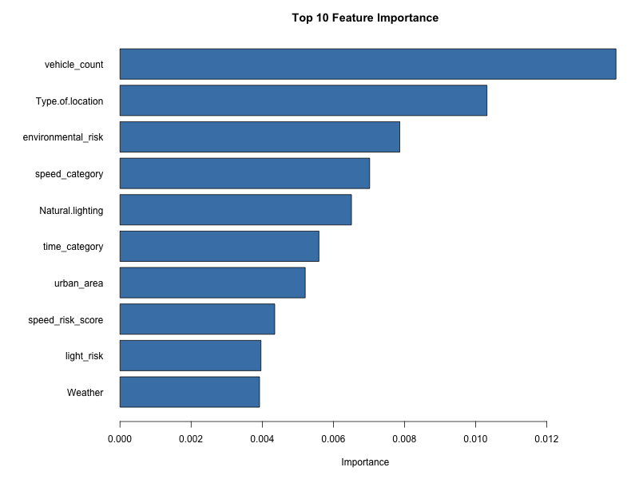

Test: Macro-ROC-AUC **0.604**, Macro-F1 **0.213**, Balanced-Acc **0.234**, Accuracy **0.336**.

# 6.3 Naive Bayes

**Model Concept**
- Fast, **probabilistic** classifier based on Bayes' theorem
- Assumes **conditional independence** of features given class

**Model Approach**
- **e1071** package with **class-weighted priors** for imbalance
- **Laplace smoothing** tuned via 5-fold CV (optimal: 0.5)

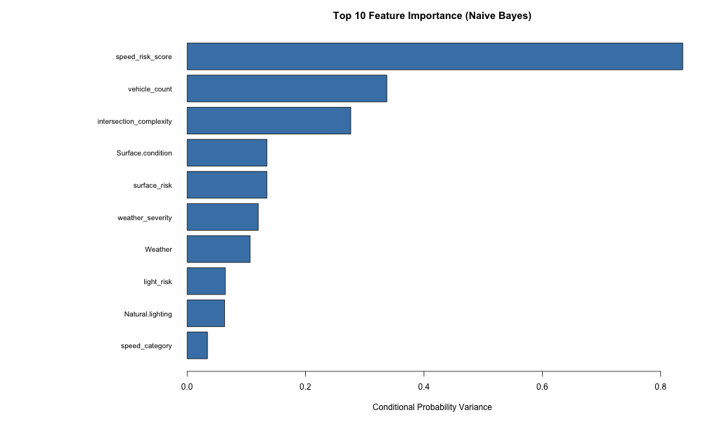

**Key Finding** **Speed risk score**, **vehicle count**, and **intersection complexity** dominate. Surface conditions and weather severity also critical for severity prediction.

**Test Performance:** Macro-F1 **0.210**, Balanced-Acc **0.259**, Macro-ROC-AUC **0.590**, Accuracy **0.272**.  
**CV:** F1 0.214±0.003, Bal-Acc 0.265±0.002 (stable across folds).

# 6.4 Decision Tree

**Model Concept**
- Tree-based classifier with **clear decision rules**.
- Recursively splits data to predict crash severity.
- Highly interpretable.

**Model Approach**
- **Two-stage grid search** for **cp** (0.0001–0.01).
- **5-fold stratified CV** with class weights.
- Best params: cp=0.0001, max-depth=30, min-split=20, min-bucket=7.
- Train: 65,445 | Test: 28,046

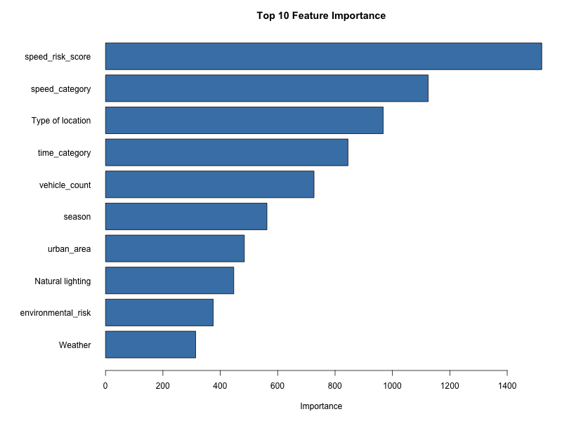

**Key Finding** **Speed risk** dominates, followed by **location type** and **time category**. Environmental factors (lighting, weather) rank lower, confirming speed/location drive severity.

Test: Macro-ROC-AUC **0.576**, Macro-F1 **0.223**, Balanced-Acc **0.308**, Accuracy **0.255**.  
CV: Macro-F1 **0.220±0.003**.

# 6.5 XGBoost

**Model Concept**
- **Gradient boosting:** Sequential tree ensemble that corrects errors
- State-of-the-art for structured/tabular data
- Handles complex interactions and non-linearity

**Model Approach**
- **Sample weighting** + **sparse matrices** (88%) + **early stopping**
- 5-fold CV tuning: **η=0.10**, depth=6, **54 trees** (from 400 max)

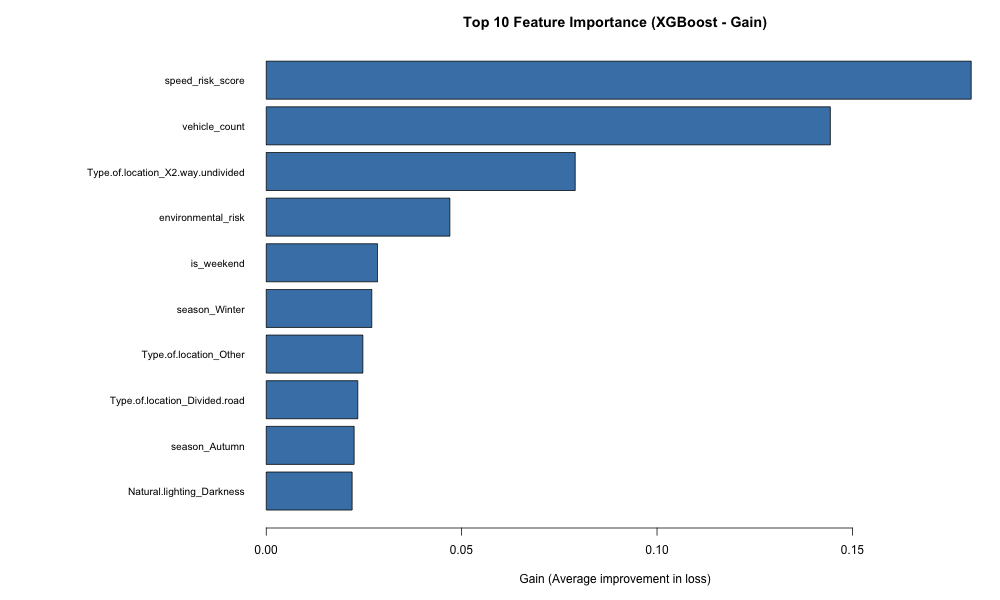

**Test Performance:** Macro-F1 **0.327**, Macro-ROC-AUC **0.694**, Accuracy **0.386**.

# 7. Model Comparison and Insights

## 7.1Model Comparison

Performance comparison across classifiers

| Model | Accuracy | MacroF1 | MacroROC |
| --- | --- | --- | --- |
| XGBoost | 38.6% | 32.7% | 69.4% |
| Random Forest | 33.6% | 21.3% | 60.4% |
| Logistic Regression | 24.2% | 20.5% | 59.4% |
| Naive Bayes | 27.2% | 21.0% | 59.0% |
| Decision Tree | 25.5% | 22.3% | 57.6% |

## 7.2 Model Insights-1

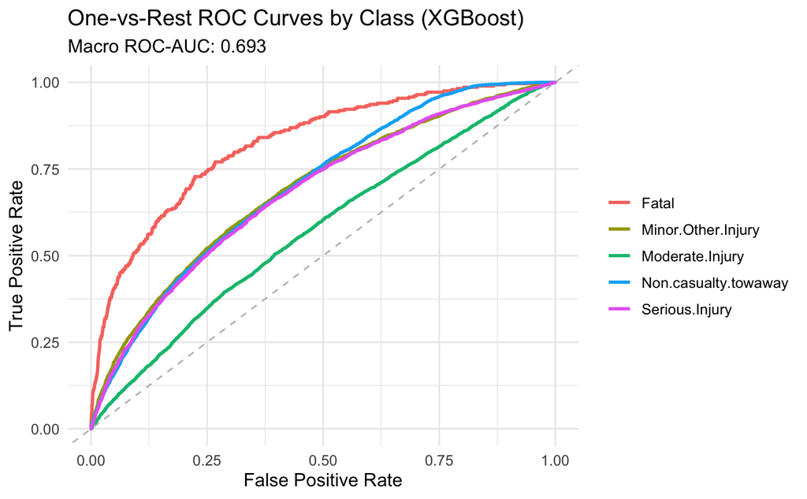

ROC

•**Fatal** accidents are clearly separated from other types; The model provides valuable insights for **preventing real-world fatal accidents**.

## 7.2 Model Insights-2

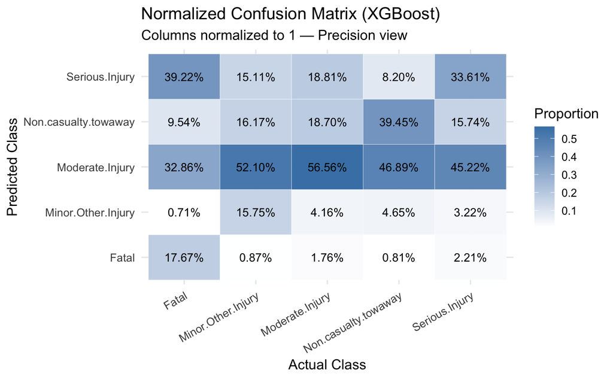

**Per-class metrics (%)**

| Class | Precision | Recall | F1 | Samples |
| --- | --- | --- | --- | --- |
| Fatal | 16.4 | 17.7 | 17.0 | 305 |
| Minor.Other.Injury | 45.7 | 15.7 | 23.4 | 1147 |
| Moderate.Injury | 31.6 | 56.6 | 40.5 | 9340 |
| Non.casualty.towaway | 52.5 | 39.4 | 45.1 | 4521 |
| Serious.Injury | 38.3 | 33.6 | 35.8 | 3383 |

**key insight **

1) a Macro ROC-AUC of 0.69, Macro F1 of 32.7%, and Weighted F1 of 39.3%.

2) 30%+  F1 scores are mainly due to **serious class imbalance** (Moderate ≈ 9,000; Fatal ≈ 300 in the test set).

4)Most predictions **fall into Moderate Injury**, showing a **conservative bias** toward class with largest samples.

## 7.3 Reality Insights

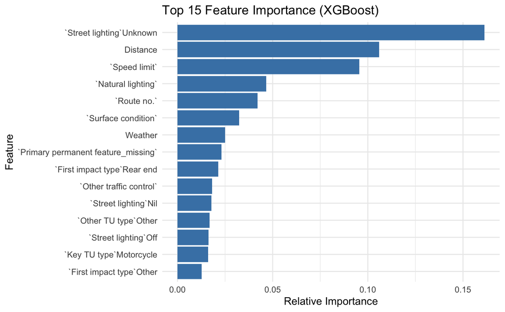

Street light distribution by class (%)

| Street_light | Fatal | Minor.Other.Injury | Moderate.Injury | Non.casualty..towaway. | Serious.Injury | SUM |
| --- | --- | --- | --- | --- | --- | --- |
| Nil | 60.39% | 18.49% | 31.78% | 11.06% | 41.05% | 25.08% |
| Off | 23.47% | 18.36% | 29.02% | 9.99% | 33.87% | 21.91% |
| On | 15.50% | 11.10% | 18.34% | 15.47% | 19.25% | 16.27% |
| Unknown / not stated | 0.63% | 52.04% | 20.86% | 63.47% | 5.83% | 36.73% |
| Sum | 100.00% | 100.00% | 100.00% | 100.00% | 100.00% | 100.00% |

2) Top1 feature-Street Lighting analysis:**Fatal (84%) and Serious (75%)** crashes in **“Nil/Off”** zones, while **others** occurs in **“Unknown/not state”** cases ,which mostly from **urban** generally with good lighting and not recorded well

# 8. Conclusion

**1️⃣ Model Performance**
XGBoost achieved the best overall performance (**Macro-F1 = 0.33, ROC = 0.69**), effectively capturing key factors that drive crash severity.

**3️⃣ High-Risk Pattern**
**Poor lighting + high-speed** conditions, form the strongest risk pattern for **fatal or serious crashes**.Besides, complex road structures show higher fatal crash rate

**4️⃣ Policy Implication**
Improving roadway **lighting** in **high-speed** and **roadway infrastructure **could **significantly reduce fatal and seriou crashes** .

/ From *Prediction* → *Prevention* /
 🚦 Using **Data** to Make Roads **Safer**

**Thank you!**